# Bitcoin Multivariate Forcast Based on Network Stats

Bob McPherson

May 8, 2019

# Introduction

Viewing data across time is inherently complex, but is necessary to be able to anticipate future trends, rather than constantly reacting to trends after they have already occurred. A good analogy for this can be found in a quote by the legendary hockey star, Wayne Gretzky. Wayne famously said that the secret to his success was that, “a good hockey player plays where the puck is. A great hockey player plays where the puck is going to be”. In the context of forecasting losses, that is all we are really trying to do: respond to where losses are likely to be, not just where they are today.

## Whitening the Time Series Data

Before analyzing time series data to search for correlations with leading indicators, we first pre-whiten all of the variables. This makes the data look more like white noise, by removing artifacts that can cause spurious correlations, such as seasonality, trend, and inherent moving average effects. This analysis removes these effects utilizing the popular ARIMA method (Auto-regressive, Integrated, Moving Average). After processing the data with ARIMA, each variable resembles white noise. It is this data set that we use to find the leading indicators that are most correlated with the target variable (which is also pre-whitened for this step).

Univariate forecasts are also be generated by the ARIMA method. These forecasts are based upon any inherent seasonality, trend, and moving average patterns found within each variable’s historical data. A graph of each forecast is shown in this section. A flat line forecast for any given variable means that there were not enough effects from trend, seasonality/cyclicality, or moving average components within the time series upon which to base a forecast. In this case, the forecast is equivalent to the mean. The whitened data set is produced by subtracting each variable’s actual values from their forecasted values.

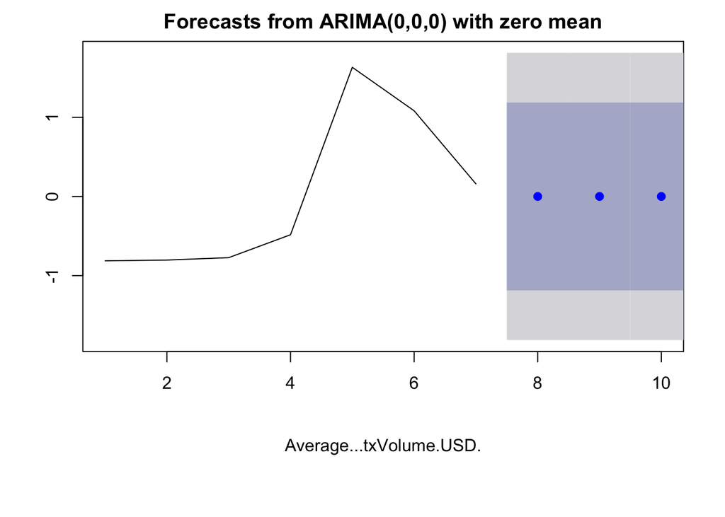

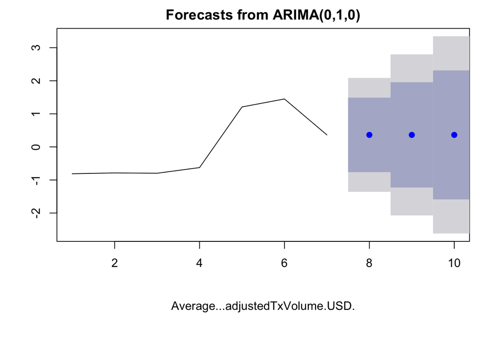

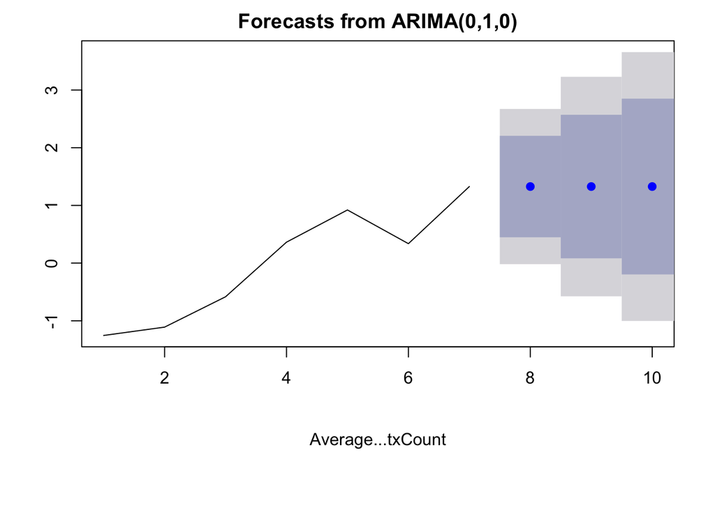

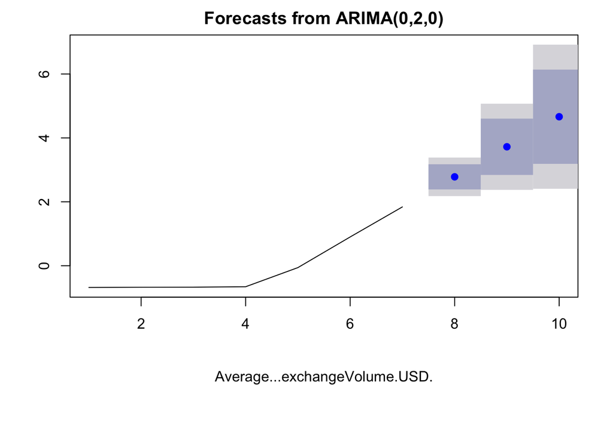

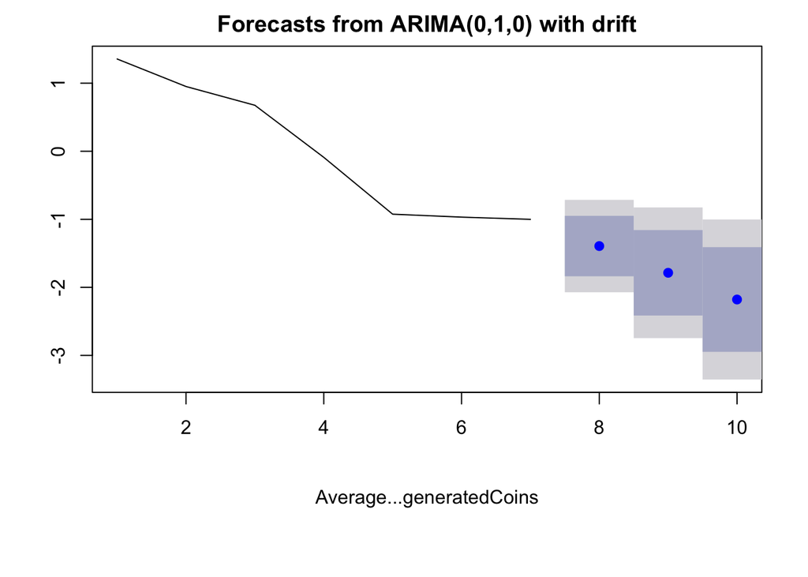

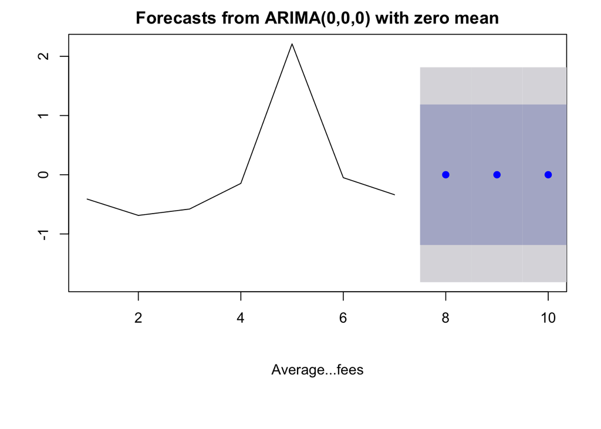

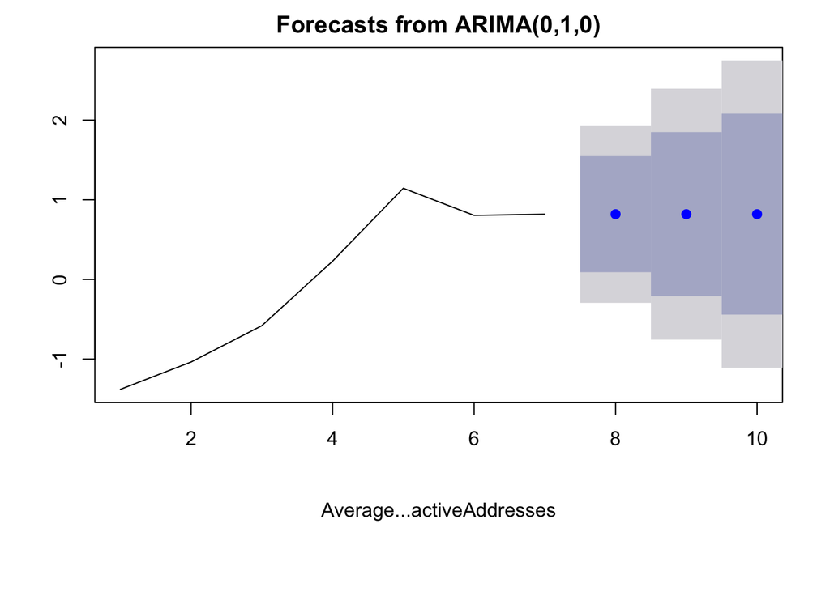

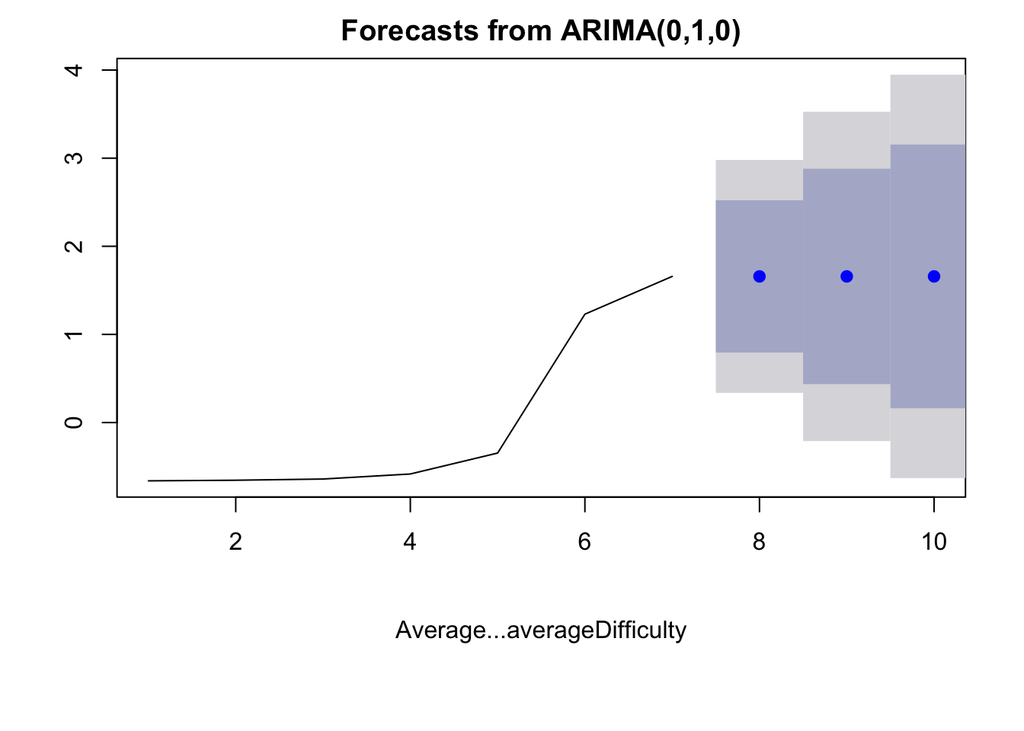

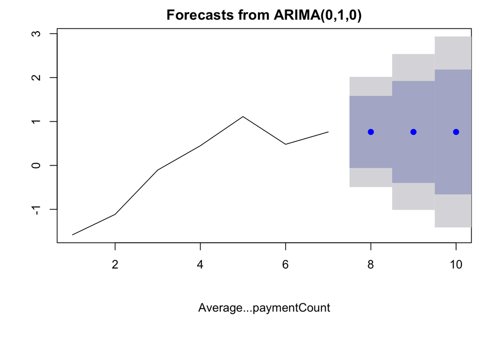

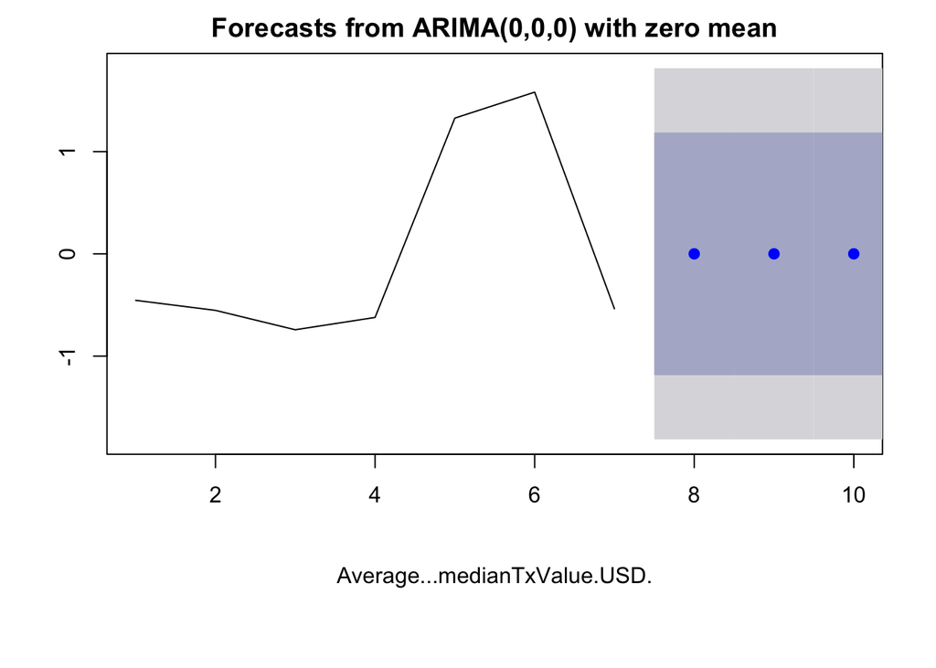

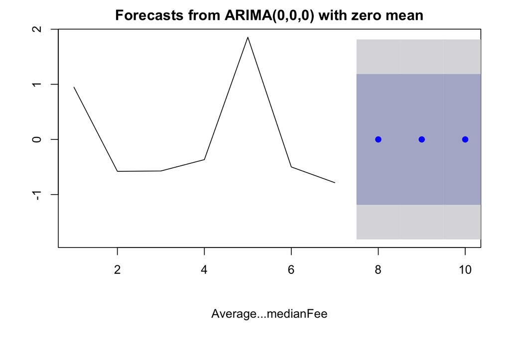

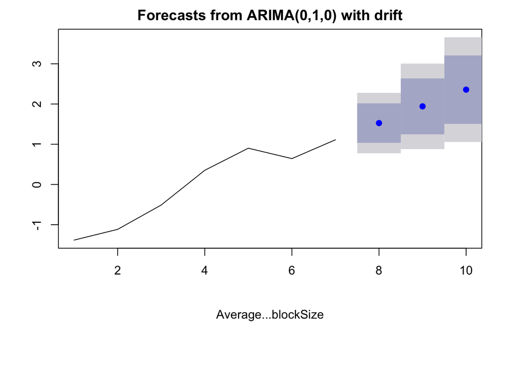

[3 more figures not shown]

## Identify Leading Indicators

This section groups leading indicators into those that are positively correlated with the target variable, and those that are negatively correlated with the target variable. The analysis uses the cross-correlation function to find significant leading indicators that are correlated with the target variable.

This process creates the graphs that follow. The vertical lines in the graphs represent correlation coefficients. The correlation coefficent levels are shown in the y-axis. The x-axis shows the lags that were tested in the analysis. The horizontal dotted lines represent statistical significance at a 95% confidence level: the upper dotted line is for positive correlations, and the lower dotted line for negative ones.

Leading indicators are considered to be those variables where the longest vertical correlation coefficient line, crosses one of the dotted significance lines, to the left of the zero in the x-axis. When this condition occurs, it means that the greatest correlation occurs when we lag the data such that the predictor variable precedes the target variable.

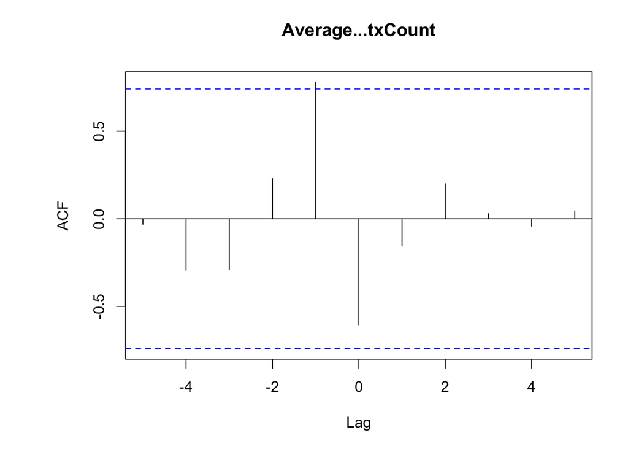

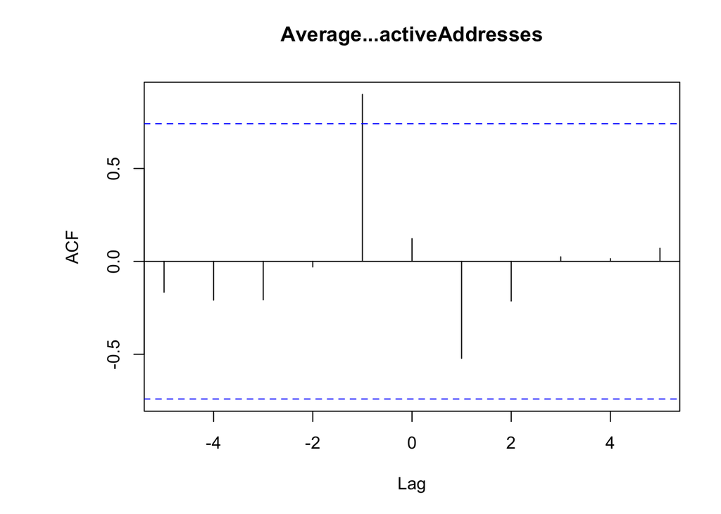

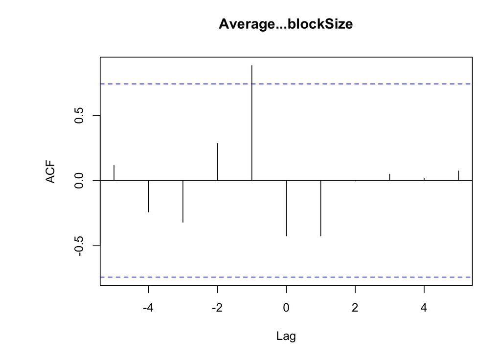

```
##
##
## Table: Positively correlated leading indicators
##
## Variable                    Cor    Lag   p_val
## --------------------------  -----  ----  ------
## Average...blockSize         0.88   -1    0.02
## Average...activeAddresses   0.9    -1    0.017
## Average...txCount           0.78   -1    0.04
##
##
## Table: Negatively correlated leading indicators
##
## Variable                   Cor     Lag   p.val
## -------------------------  ------  ----  ------
## Average...medianFee        -0.75   -2    0.048
## Average...generatedCoins   -0.84   -1    0.026
```

[output not shown]

[figure not shown]

# Forecasting

The leading indicators in the preceding step are assembled into a matrix that is used to generate a predictive model based on a GLMNet algorithm. Although this is a regularized regression method that can be used to deal with micro arrays such as this, where the number of columns exceeds the number of rows, the width of this data set was creating computational challenges. The GLMNet forecast was run on only leading indicator variables to make the compute process more tractable. Other methods can be explored to attempt to utilize all of the data, such as dimensionality reduction techniques (e.g., principal components for time series, or singular spectrum analysis); Bayesian Vector Auto Regression (BVAR) with regularization; and deep learning algorithms (e.g., recurrent neural networks).

The figure below shows the standard error ranges of a GLMNet model fitted to the data. It helps in estimating the best number of variables, as well as the best penalty value for the shrinkage weighting parameter (i.e., best lambda value).

## GLMNet Model

The figure below shows the forecast versus the actual, based on the resulting GLMNet model on the leading indicators.

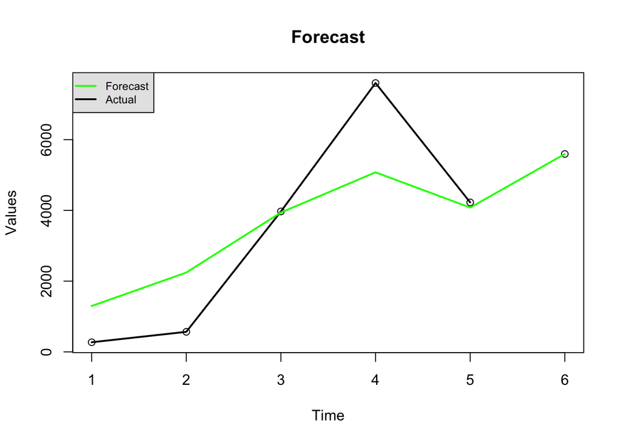

| Forecast (most recent at the bottom) |
| --- |
| 5595.191 |

## GLMNet Coefficients

Following are the coefficients selected by LASSO regression. The first table shows all of the leading indicators that were considered in the algorithm, including those that were not selected by it, as indicated by a coefficient of zero. The second table isolates just those coefficients that are non-zero, and are included in the final model.

Coefficients on Pre-Whitened Time Series Data

| Variable | Coefficient |
| --- | --- |
| y-intercept | 3314.45705160436 |
| Average…blockSize | 0 |
| Average…activeAddresses | 311.48697813107 |
| Average…txCount | 1526.52311004051 |
| Average…medianFee | 0 |
| Average…generatedCoins | 0 |

If we isolate all of the non-zero coefficients to show only those variables that were selected to be included in the final model by the LASSO feature selection algorithm, the short list of variables appears as follows.

GLMNet Coefficients

| Variable | Coefficient |
| --- | --- |
| y-intercept | 3314.45705160436 |
| Average…activeAddresses | 311.48697813107 |
| Average…txCount | 1526.52311004051 |

## BVAR Forecast

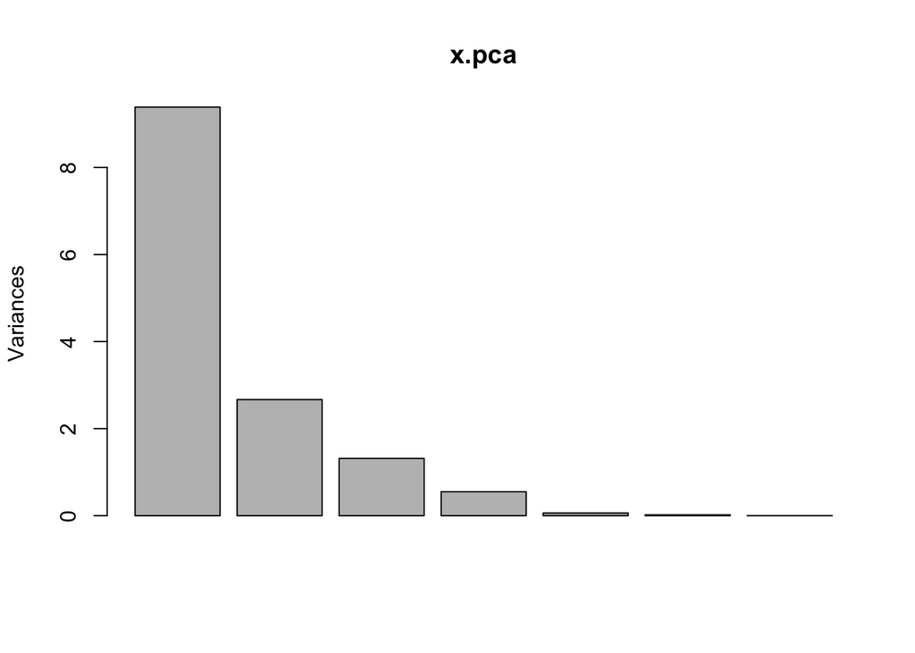

Predictions: oldest at top, newest at bottom

| x |
| --- |
| 452.3962 |
| 451.8830 |
| 451.8844 |

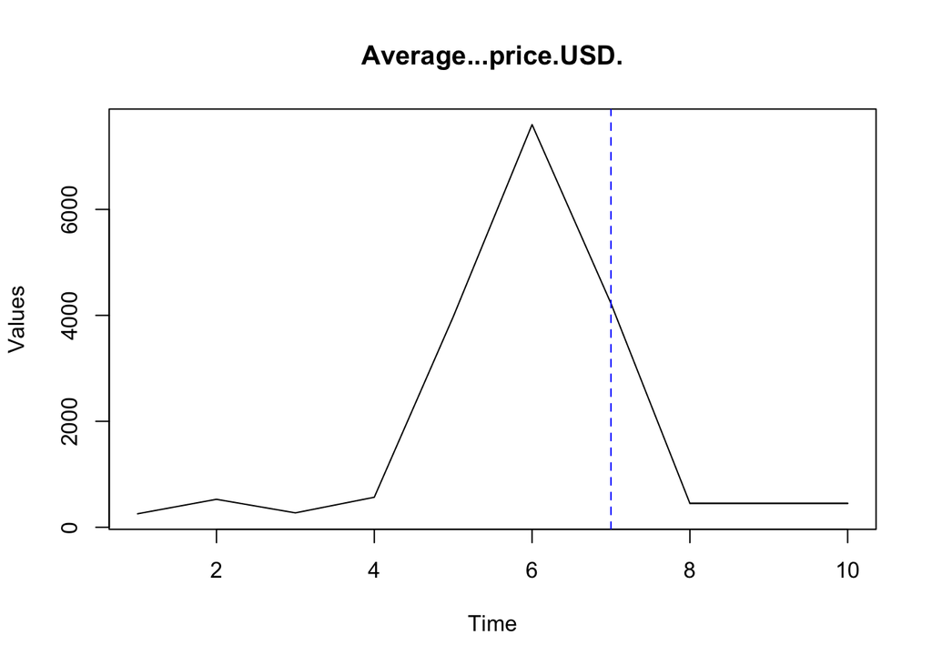

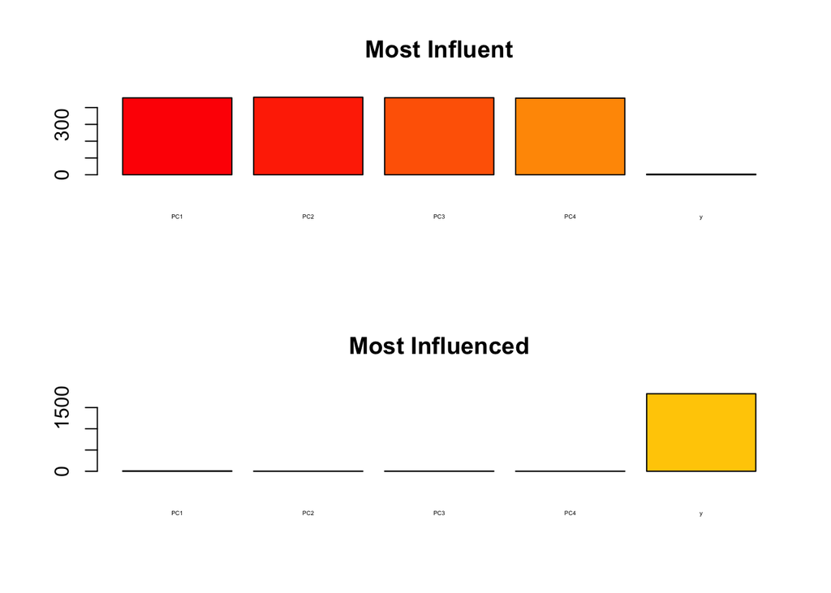